# Copy_of_hw5

## EuroSAT Land Use and Land Cover Classification using Deep Learning

In this exercise, I implemented deep learning models to solve a typical problem in satellite imaging using a benchmark dataset. Both multilayer perceptron (MLP) and convolutional neural network (CNN) are used to label the EuroSAT satellite images (27010 images) with the correct land use classifications. This notebook consists of several sections that train the EuroSAT images with increasingly more complex models, from the single-layer neural net to transfer learning of VGG16. The accuracies improved from 16.8% to 88.8%.

### S1:

- Visit the EuroSAT data description page and download the data: https://github.com/phelber/eurosat
- Split the data into training (50%) and testing sets (50%), stratified on class labels (equal percentage of each class type in train and test sets).

```python
from google.colab import drive
drive.mount('/content/drive')
```

```
Go to this URL in a browser: https://accounts.google.com/o/oauth2/auth?client_id=947318989803-6bn6qk8qdgf4n4g3pfee6491hc0brc4i.apps.googleusercontent.com&redirect_uri=urn%3aietf%3awg%3aoauth%3a2.0%3aoob&response_type=code&scope=email%20https%3a%2f%2fwww.googleapis.com%2fauth%2fdocs.test%20https%3a%2…

Enter your authorization code:
··········
```

```python
from __future__ import print_function
import pandas as pd
import numpy as np
import os
from tqdm import tqdm

import keras
from keras.datasets import mnist
from keras.models import Sequential
from keras.layers import Dense, Dropout, Flatten, Conv2D, MaxPooling2D, Input, GlobalAveragePooling2D
from keras.optimizers import RMSprop, Adam, SGD, Adadelta
from keras.utils import plot_model
from keras import backend as K

import matplotlib.image as mpimg
import matplotlib.pyplot as plt
from matplotlib.pyplot import imread, imshow, subplots, show

from skimage.color import rgb2gray
from sklearn.metrics import accuracy_score, confusion_matrix, roc_auc_score
from sklearn.preprocessing import StandardScaler
from sklearn.preprocessing import MinMaxScaler
from sklearn.decomposition import PCA
from sklearn.model_selection import train_test_split, StratifiedShuffleSplit, StratifiedKFold, cross_val_score, cross_validate, cross_val_predict
```

```python
# reading the data
import glob
import os
imgdir='/content/drive/My Drive/Colab Notebooks/MUSA650/EuroSAT'
imgfiles = []
for file in glob.glob(imgdir + os.sep + "*" + os.sep + "*.jpg"):
  imgfiles.append(file)
```

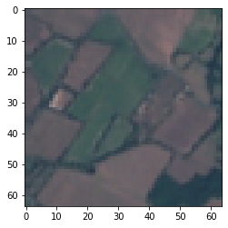

```python
# plot the first img
tmpimg = imread(imgfiles[0])
imshow(tmpimg)
show()
```

```python
### TAKES A LONG TIME TO RUN, AVOID RE-RUN !!! ###
eurosat = []
eurosat_label = []
for row in imgfiles:
  tmpimg = imread(row)
  gray_img = rgb2gray(tmpimg).reshape(1, 4096).squeeze().flatten() #flatten and convert to gray scale
  eurosat.append(gray_img) #append to the feature data set
  label = row.split("/")[7]
  eurosat_label.append(label) #append to the label list
```

```python
# flatten the list of arrays into matrix
eurosat_f = np.vstack(eurosat)
eurosat_label_f = np.vstack(eurosat_label).reshape(27010,)
```

```python
# change label to integers
dictionary = {"AnnualCrop":0, "Forest":1, "HerbaceousVegetation":2, "Highway":3,
              "Industrial":4, "Pasture":5, "PermanentCrop":6, "Residential":7, "River":8, "SeaLake":9}
eurosat_label_f = [dictionary[letter] for letter in eurosat_label_f]
```

```python
eurosat_label_f = np.vstack(eurosat_label_f).reshape(27010,)
```

```python
# split into 50%/50% training and testing set
X_train, X_test, y_train, y_test = train_test_split(eurosat_f, eurosat_label_f, stratify = eurosat_label_f, train_size = 0.5, random_state= 10)
```

```python
X_train.shape
```

```
(13505, 4096)
```

```python
y_train.shape
```

```
(13505,)
```

### S2:

- Convert each RBG image to grayscale and flatten the images into a data matrix (n x p: n = #samples, p = #pixels in each image)
- Implement a first deep learning model (M.1) using a fully connected network with a single fully connected layer (i.e: input layer + fully connected layer as the output layer).
- Q1: Calculate classification accuracy on the test data.

  16.8%

```python
# first step done in S1
```

```python
# set global params
batch_size = 1200
num_classes = 10
epochs = 10
```

```python
# convert class vectors to binary class matrices
y_train = keras.utils.to_categorical(y_train, num_classes)
y_test = keras.utils.to_categorical(y_test, num_classes)
```

```python
## First deep learning model M.1
model = Sequential()
model.add(Dense(num_classes, activation='softmax', input_shape=(4096,)))

model.summary()
```

```
Model: "sequential_21"
_________________________________________________________________
Layer (type)                 Output Shape              Param #
=================================================================
dense_36 (Dense)             (None, 10)                40970
=================================================================
Total params: 40,970
Trainable params: 40,970
Non-trainable params: 0
_________________________________________________________________
```

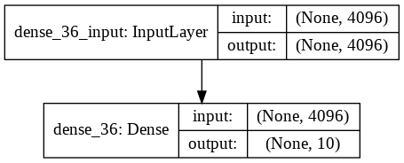

```python
# visualize model
plot_model(model, show_shapes=True, show_layer_names=True)
```

```python
# complie the model
model.compile(loss='categorical_crossentropy',
              optimizer=Adam(),
              metrics=['accuracy'])
```

```python
# fit the model
history = model.fit(X_train, y_train,
                    batch_size=batch_size,
                    epochs=epochs,
                    verbose=1,
                    validation_data=(X_test, y_test))
```

```
Train on 13505 samples, validate on 13505 samples
```

```python
# evaluate the model
score = model.evaluate(X_test, y_test, verbose=0)
print('Test loss:', score[0])
print('Test accuracy:', score[1])
```

```
Test loss: 2.1948902905141807
Test accuracy: 0.16808588802814484
```

### S3:

- Implement a second deep learning model (M.2) adding an additional fully connected hidden layer (with an arbitrary number of nodes) to the previous model.
- Q1: Calculate classification accuracy on the test data.

21.2%

```python
## Second deep learning model M.2
model = Sequential()
model.add(Dense(800, activation='relu', input_shape=(4096,)))
model.add(Dense(num_classes, activation='softmax'))

model.summary()
```

```
Model: "sequential_22"
_________________________________________________________________
Layer (type)                 Output Shape              Param #
=================================================================
dense_37 (Dense)             (None, 800)               3277600
_________________________________________________________________
dense_38 (Dense)             (None, 10)                8010
=================================================================
Total params: 3,285,610
Trainable params: 3,285,610
Non-trainable params: 0
_________________________________________________________________
```

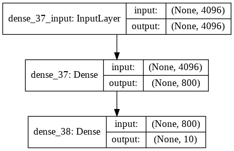

```python
# visualize model
plot_model(model, show_shapes=True, show_layer_names=True)
```

```python
# complie the model
model.compile(loss='categorical_crossentropy',
              optimizer=Adam(),
              metrics=['accuracy'])
```

```python
# fit the model
history = model.fit(X_train, y_train,
                    batch_size=batch_size,
                    epochs=15,
                    verbose=1,
                    validation_data=(X_test, y_test))
```

```
Train on 13505 samples, validate on 13505 samples
```

```python
# evaluate the model
score = model.evaluate(X_test, y_test, verbose=0)
print('Test loss:', score[0])
print('Test accuracy:', score[1])
```

```
Test loss: 2.1400763732333927
Test accuracy: 0.21192151308059692
```

### S4:

- Implement a third deep learning model (M.3) adding two additional fully connected hidden layers (with arbitrary number of nodes) as well as drop-out layers to the previous model.
- Q1: Calculate classification accuracy on the test data.

  28.0%
- Q2: Compare against previous models. Which model was the "best"? Why?

The M.3 model was the "best". It has the highest accuracy with only 10 epochs. The multiple layers of neurons as well as the drop outs make the model more robust and avoid overfitting.

```python
## Third deep learning model M.3
model = Sequential()
model.add(Dense(2700, activation='relu', input_shape=(4096,)))
model.add(Dropout(0.2))
model.add(Dense(1800, activation='relu'))
model.add(Dropout(0.2))
model.add(Dense(800, activation='relu'))
model.add(Dropout(0.2))
model.add(Dense(num_classes, activation='softmax'))

model.summary()
```

```
Model: "sequential_23"
_________________________________________________________________
Layer (type)                 Output Shape              Param #
=================================================================
dense_39 (Dense)             (None, 2700)              11061900
_________________________________________________________________
dropout_4 (Dropout)          (None, 2700)              0
_________________________________________________________________
dense_40 (Dense)             (None, 1800)              4861800
_________________________________________________________________
dropout_5 (Dropout)          (None, 1800)              0
_________________________________________________________________
dense_41 (Dense)             (None, 800)               1440800
_________________________________________________________________
dropout_6 (Dropout)          (None, 800)               0
_________________________________________________________________
dense_42 (Dense)             (None, 10)                8010
=================================================================
Total params: 17,372,510
Trainable params: 17,372,510
Non-trainable params: 0
_________________________________________________________________
```

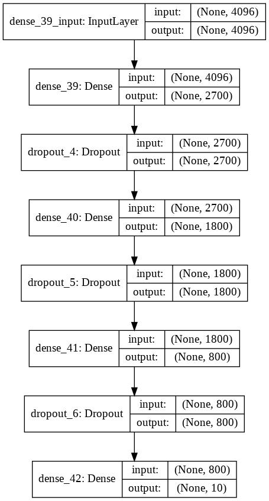

```python
# visualize model
plot_model(model, show_shapes=True, show_layer_names=True)
```

```python
# complie the model
model.compile(loss='categorical_crossentropy',
              optimizer=Adam(),
              metrics=['accuracy'])
```

```python
# fit the model
history = model.fit(X_train, y_train,
                    batch_size=batch_size,
                    epochs=epochs,
                    verbose=1,
                    validation_data=(X_test, y_test))
```

```
Train on 13505 samples, validate on 13505 samples
```

```python
# evaluate the model
score = model.evaluate(X_test, y_test, verbose=0)
print('Test loss:', score[0])
print('Test accuracy:', score[1])
```

```
Test loss: 1.9996189414814904
Test accuracy: 0.28034061193466187
```

### S5:

- Using RGB images (without vectorizing them), implement a fourth CNN model (M.4) that includes the following layers: Conv2D, MaxPooling2D, Dropout, Flatten, Dense.
- Q1: Calculate classification accuracy on the test data.

50.3%

- Q2: Compare against previous models. Which model was the "best"? Why?

This model is much better than the previous models. This is because the inclusion of the convolutional layers that captures the image relational features.

```python
# load RGB images
RGB_eurosat = []
for row in imgfiles:
  tmpimg = imread(row)
  RGB_eurosat.append(tmpimg) #append to the feature data set
```

```python
# list to matrix
RGB_eurosat_f = np.stack(RGB_eurosat)
```

```python
input_shape = (64, 64, 3)
```

```python
# split into 50%/50% training and testing set
X_train, X_test, y_train, y_test = train_test_split(RGB_eurosat_f, eurosat_label_f, stratify = eurosat_label_f, train_size = 0.5, random_state= 10)
```

```python
X_train.shape
```

```
(13505, 64, 64, 3)
```

```python
# convert class vectors to binary class matrices
y_train = keras.utils.to_categorical(y_train, num_classes)
y_test = keras.utils.to_categorical(y_test, num_classes)
```

```python
## Fourth deep learning model M.4
model = Sequential()
model.add(Conv2D(64, kernel_size=(3, 3),
                 activation='relu',
                 input_shape=input_shape,
                 data_format='channels_last', padding = "same"))
model.add(MaxPooling2D(pool_size=(3, 3), padding = "same"))
model.add(Dropout(0.25))
model.add(Flatten())
model.add(Dense(num_classes, activation='softmax'))
```

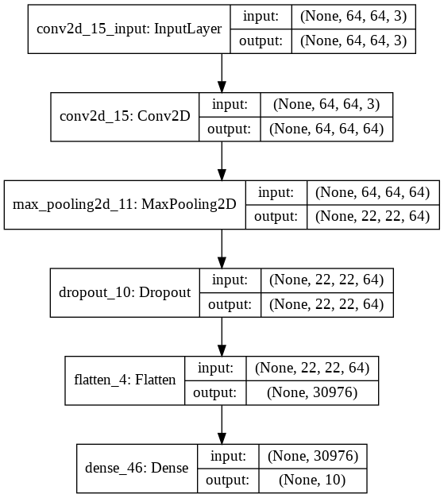

```python
# visualize model
plot_model(model, show_shapes=True, show_layer_names=True)
```

```python
# complie the model
model.compile(loss='categorical_crossentropy',
              optimizer=Adam(),
              metrics=['accuracy'])
```

```python
# fit the model
history = model.fit(X_train, y_train,
                    batch_size=batch_size,
                    epochs=epochs,
                    verbose=1,
                    validation_data=(X_test, y_test))
```

```
Train on 13505 samples, validate on 13505 samples
```

```python
# evaluate the model
score = model.evaluate(X_test, y_test, verbose=0)
print('Test loss:', score[0])
print('Test accuracy:', score[1])
```

```
Test loss: 1.3995577849974592
Test accuracy: 0.5030729174613953
```

### S6:

- Using RGB images (without vectorizing them), implement a fifth deep learning model (M.5) targeting accuracy that will outperform all previous models. You are free to use any tools and techniques, as well as pre-trained models for transfer learning.
- Q1: Describe the model you built, and why you chose it.

  The first trial uses multiple convolutional layers, as well as max pooling, dense, and drop out layers. A second trial was done with transfer learning with the VGG16 model which gives the best model for this section. This model relies on the pre-trained VGG16 model weights. The architecture here uses the VGG16 model weights with variation in the output class numbers. VGG16 was chosen because it has trained on a large dataset with multiple kinds of images, which means it captures the basic image features(filters) well.
- Q2: Calculate classification accuracy on the test data.

  88.8%
- Q3: Compare against previous models. Which model was the "best"? Why?

  The model using VGG16 weights outperforms all the previous model. This is because VGG16 was trained on a large dataset with an neural net architecture that has tested to be good at capturing the image features.
- Q4: What are the two classes with the highest labeling error? Explain using data and showing mis-classified examples.

  Class 6(PermanentCrop) is prone to be misclassified as class 2(HerbaceousVegetation), and class 8(River) is prone to be misclassfied as class 3(Highway).

```python
## Fifth deep learning model M.5 trial 1
model = Sequential()
model.add(Conv2D(64, kernel_size=(3, 3),
                 activation='relu',
                 input_shape=input_shape,
                 data_format='channels_last', padding = "same"))
model.add(Conv2D(64, kernel_size=(3, 3),
                 activation='relu',
                 data_format='channels_last', padding = "same"))
model.add(MaxPooling2D(pool_size=(3, 3), padding = "same"))
model.add(Conv2D(128, kernel_size=(3, 3),
                 activation='relu',
                 data_format='channels_last', padding = "same"))
model.add(MaxPooling2D(pool_size=(3, 3), padding = "same"))
model.add(Dropout(0.25))
model.add(Flatten())
model.add(Dense(800, activation='relu'))
model.add(Dropout(0.25))
model.add(Dense(num_classes, activation='softmax'))
```

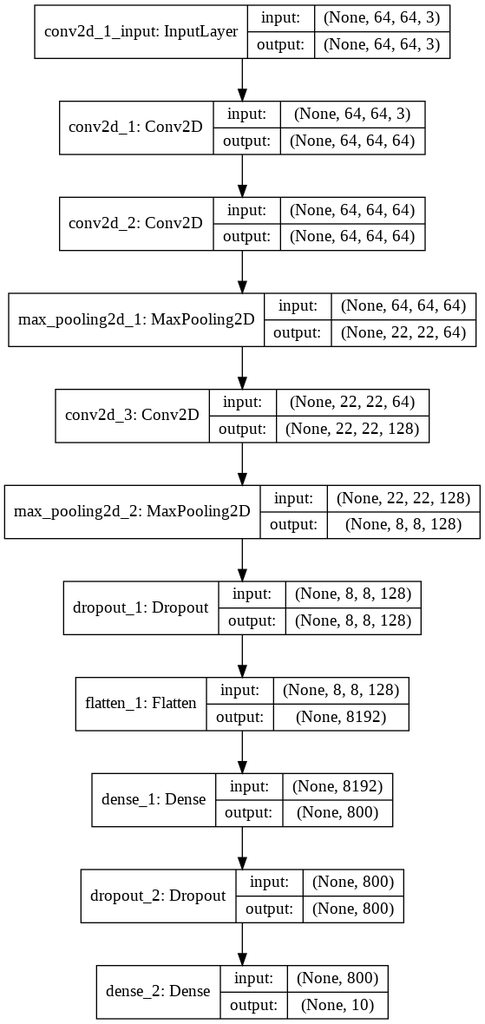

```python
# visualize model
plot_model(model, show_shapes=True, show_layer_names=True)
```

```python
# complie the model
model.compile(loss='categorical_crossentropy',
              optimizer=Adam(),
              metrics=['accuracy'])
```

```python
# fit the model
history = model.fit(X_train, y_train,
                    batch_size=batch_size,
                    epochs=epochs,
                    verbose=1,
                    validation_data=(X_test, y_test))
```

```
Train on 13505 samples, validate on 13505 samples
```

```python
# evaluate the model
score = model.evaluate(X_test, y_test, verbose=0)
print('Test loss:', score[0])
print('Test accuracy:', score[1])
```

```
Test loss: 0.8138929843108154
Test accuracy: 0.7115142345428467
```

```python
## Fifth deep learning model M.5 trial 2 (with VGG16 model weights)
from keras.models import Model
# load vgg model
from keras.applications.vgg16 import VGG16, preprocess_input
from keras.applications.inception_v3 import InceptionV3, preprocess_input
```

```python
# load the model
base_model = VGG16(weights='imagenet', include_top=False)
#base_model = InceptionV3(weights='imagenet', include_top=False)
```

```python
base_model.summary()
```

```
Model: "vgg16"
_________________________________________________________________
Layer (type)                 Output Shape              Param #
=================================================================
input_1 (InputLayer)         (None, None, None, 3)     0
_________________________________________________________________
block1_conv1 (Conv2D)        (None, None, None, 64)    1792
_________________________________________________________________
block1_conv2 (Conv2D)        (None, None, None, 64)    36928
_________________________________________________________________
block1_pool (MaxPooling2D)   (None, None, None, 64)    0
_________________________________________________________________
block2_conv1 (Conv2D)        (None, None, None, 128)   73856
_________________________________________________________________
block2_conv2 (Conv2D)        (None, None, None, 128)   147584
_________________________________________________________________
block2_pool (MaxPooling2D)   (None, None, None, 128)   0
_________________________________________________________________
block3_conv1 (Conv2D)        (None, None, None, 256)   295168
_________________________________________________________________
block3_conv2 (Conv2D)        (None, None, None, 256)   590080
_________________________________________________________________
block3_conv3 (Conv2D)        (None, None, None, 256)   590080
_________________________________________________________________
block3_pool (MaxPooling2D)   (None, None, None, 256)   0
_________________________________________________________________
block4_conv1 (Conv2D)        (None, None, None, 512)   1180160
_________________________________________________________________
block4_conv2 (Conv2D)        (None, None, None, 512)   2359808
_________________________________________________________________
block4_conv3 (Conv2D)        (None, None, None, 512)   2359808
_________________________________________________________________
block4_pool (MaxPooling2D)   (None, None, None, 512)   0
_________________________________________________________________
block5_conv1 (Conv2D)        (None, None, None, 512)   2359808
_________________________________________________________________
block5_conv2 (Conv2D)        (None, None, None, 512)   2359808
_________________________________________________________________
block5_conv3 (Conv2D)        (None, None, None, 512)   2359808
_________________________________________________________________
block5_pool (MaxPooling2D)   (None, None, None, 512)   0
=================================================================
Total params: 14,714,688
Trainable params: 14,714,688
Non-trainable params: 0
_________________________________________________________________
```

```python
# freeze the model weights
for layer in base_model.layers:
    layer.trainable = False
```

```python
# construct model
x = base_model.output
x = GlobalAveragePooling2D(name='avg_pool')(x)
x = Dropout(0.4)(x)
predictions = Dense(num_classes, activation='softmax')(x)
model = Model(inputs=base_model.input, outputs=predictions)
```

```python
model.compile(optimizer=Adam(),
              loss='categorical_crossentropy',
              metrics=['accuracy'])
```

```python
model.summary()
```

```
Model: "model_8"
_________________________________________________________________
Layer (type)                 Output Shape              Param #
=================================================================
input_6 (InputLayer)         (None, None, None, 3)     0
_________________________________________________________________
block1_conv1 (Conv2D)        (None, None, None, 64)    1792
_________________________________________________________________
block1_conv2 (Conv2D)        (None, None, None, 64)    36928
_________________________________________________________________
block1_pool (MaxPooling2D)   (None, None, None, 64)    0
_________________________________________________________________
block2_conv1 (Conv2D)        (None, None, None, 128)   73856
_________________________________________________________________
block2_conv2 (Conv2D)        (None, None, None, 128)   147584
_________________________________________________________________
block2_pool (MaxPooling2D)   (None, None, None, 128)   0
_________________________________________________________________
block3_conv1 (Conv2D)        (None, None, None, 256)   295168
_________________________________________________________________
block3_conv2 (Conv2D)        (None, None, None, 256)   590080
_________________________________________________________________
block3_conv3 (Conv2D)        (None, None, None, 256)   590080
_________________________________________________________________
block3_pool (MaxPooling2D)   (None, None, None, 256)   0
_________________________________________________________________
block4_conv1 (Conv2D)        (None, None, None, 512)   1180160
_________________________________________________________________
block4_conv2 (Conv2D)        (None, None, None, 512)   2359808
_________________________________________________________________
block4_conv3 (Conv2D)        (None, None, None, 512)   2359808
_________________________________________________________________
block4_pool (MaxPooling2D)   (None, None, None, 512)   0
_________________________________________________________________
block5_conv1 (Conv2D)        (None, None, None, 512)   2359808
_________________________________________________________________
block5_conv2 (Conv2D)        (None, None, None, 512)   2359808
_________________________________________________________________
block5_conv3 (Conv2D)        (None, None, None, 512)   2359808
_________________________________________________________________
block5_pool (MaxPooling2D)   (None, None, None, 512)   0
_________________________________________________________________
avg_pool (GlobalAveragePooli (None, 512)               0
_________________________________________________________________
dropout_5 (Dropout)          (None, 512)               0
_________________________________________________________________
dense_4 (Dense)              (None, 10)                5130
=================================================================
Total params: 14,719,818
Trainable params: 5,130
Non-trainable params: 14,714,688
_________________________________________________________________
```

```python
# fit the model
history = model.fit(X_train, y_train,
                    batch_size=500,
                    epochs=12,
                    verbose=1,
                    validation_data=(X_test, y_test))
```

```
Train on 13505 samples, validate on 13505 samples
```

```python
# evaluate the model
score = model.evaluate(X_test, y_test, verbose=0)
print('Test loss:', score[0])
print('Test accuracy:', score[1])
```

```
Test loss: 0.3766734523619382
Test accuracy: 0.8883376717567444
```

```python
# check labeling error of each class
results = model.predict(X_test)
```

```python
results
```

```
array([[2.4133356e-01, 7.3351913e-10, 8.1162510e-10, ..., 5.9573291e-10,
        7.5440884e-01, 1.6310478e-08],
       [1.9804563e-01, 2.4410190e-02, 4.3836786e-07, ..., 9.6854683e-06,
        1.5316344e-02, 1.9544849e-02],
       [2.0079828e-04, 8.7549537e-02, 1.2287562e-03, ..., 5.4740848e-04,
        3.4269638e-04, 9.0904033e-01],
       ...,
       [9.3672252e-01, 8.8067819e-23, 3.0530498e-11, ..., 9.3517274e-09,
        3.2298265e-06, 3.3727824e-20],
       [2.2811066e-16, 0.0000000e+00, 2.0683032e-26, ..., 3.4997865e-09,
        3.4882233e-17, 0.0000000e+00],
       [6.8968498e-12, 4.7158712e-24, 6.3914107e-10, ..., 9.1521198e-01,
        4.2880635e-07, 2.5439743e-23]], dtype=float32)
```

```python
y_pred = np.argmax(results,axis=1)
```

```python
y_test1 = np.argmax(y_test,axis=1)
```

```python
confusion_matrix(y_test1, y_pred)
```

```
array([[1346,    2,    0,   34,    1,   49,   49,    0,   19,    5],
       [   1, 1419,   17,    2,    0,   35,    1,    2,    4,   19],
       [   1,   22, 1391,    5,    2,   24,   32,   18,    5,    0],
       [  37,    4,   27, 1006,   25,   36,   33,   19,   62,    1],
       [   5,    0,    1,   29, 1129,    3,   26,   51,    6,    0],
       [   4,   24,   18,   10,    0,  928,    7,    1,    7,    1],
       [  38,    1,  128,   30,   21,   51,  944,   25,   12,    0],
       [   0,   15,   28,    7,   32,    7,    8, 1398,    5,    0],
       [  35,    4,   21,  122,    9,   55,    4,    5,  988,    7],
       [   2,   24,    4,    5,    0,    7,    0,    0,   10, 1448]])
```

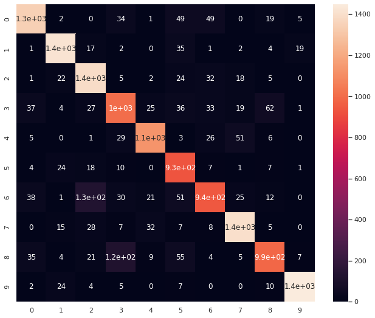

```python
import seaborn as sn
import pandas as pd
import matplotlib.pyplot as plt

array = confusion_matrix(y_test1, y_pred)

df_cm = pd.DataFrame(array, range(10), range(10))

plt.figure(figsize=(11,9))
sn.set(font_scale=1) # for label size
sn.heatmap(df_cm, annot=True, annot_kws={"size": 12}) # font size

plt.show()
```

```python
dictionary
```

```
{'AnnualCrop': 0,
 'Forest': 1,
 'HerbaceousVegetation': 2,
 'Highway': 3,
 'Industrial': 4,
 'Pasture': 5,
 'PermanentCrop': 6,
 'Residential': 7,
 'River': 8,
 'SeaLake': 9}
```

```python
# Class 6(PermanentCrop) is prone to be misclassified as class 2(HerbaceousVegetation),
# and class 8(River) is prone to be misclassfied as class 3(Highway).
```

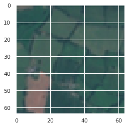

```python
# successfully identified class 6 (PermanentCrop) image example:
trial1 = np.where((y_test1== 6) & (y_pred == 6))[0][1]
tmpimg = imread(imgfiles[trial1])
imshow(tmpimg)
show()
```

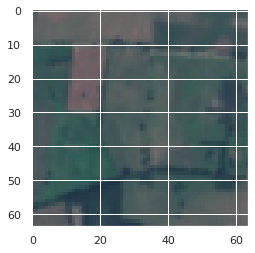

```python
# successfully identified class 2 (HerbaceousVegetation) image example:
trial1 = np.where((y_test1== 2) & (y_pred == 2))[0][10]
tmpimg = imread(imgfiles[trial1])
imshow(tmpimg)
show()
```

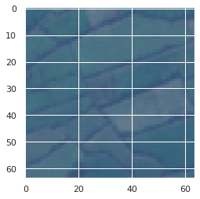

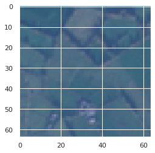

```python
# show some misclassified examples:
# select a few class 6 images that were miclassified as class 2:
trial1 = np.where((y_test1== 6) & (y_pred == 2))[0][1]
tmpimg = imread(imgfiles[trial1])
imshow(tmpimg)
show()
trial2 = np.where((y_test1== 6) & (y_pred == 2))[0][5]
tmpimg = imread(imgfiles[trial2])
imshow(tmpimg)
show()
```

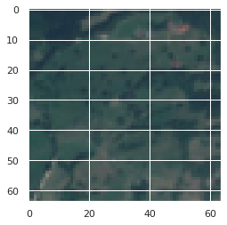

```python
# successfully identified class 8 (River) image example:
trial1 = np.where((y_test1== 8) & (y_pred == 8))[0][15]
tmpimg = imread(imgfiles[trial1])
imshow(tmpimg)
show()
```

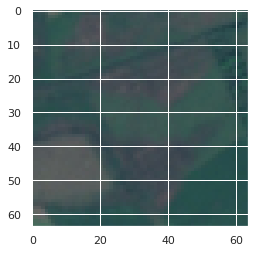

```python
# successfully identified class 3 (Highway) image example:
trial1 = np.where((y_test1== 3) & (y_pred == 3))[0][15]
tmpimg = imread(imgfiles[trial1])
imshow(tmpimg)
show()
```

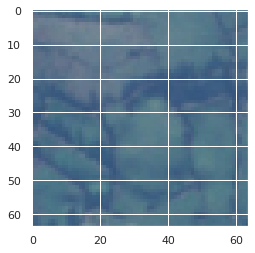

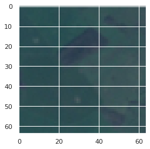

```python
# select a few class 8 images that were miclassified as class 3:
trial1 = np.where((y_test1== 8) & (y_pred == 3))[0][1]
tmpimg = imread(imgfiles[trial1])
imshow(tmpimg)
show()
trial2 = np.where((y_test1== 8) & (y_pred == 3))[0][5]
tmpimg = imread(imgfiles[trial2])
imshow(tmpimg)
show()
```